# Fakultät für Physik

## Physikalisches Praktikum P2 für Studierende der Physik

Versuch P2-41, 42, 22 (Stand: April 2024)

[Raum F1-19](https://labs.physik.kit.edu/img/Praktikum/Lageplan_P2.png)

# Vakuum

Name: Alhelo Vorname: Fadi E-Mail: uylex@student.kit.edu

\begin{equation*} \begin{split} &\\ &\\ \end{split} \end{equation*}

Name: Ji Vorname: Tony E-Mail: uvsvo@student.kit.edu

\begin{equation*} \begin{split} &\\ &\\ &\\ \end{split} \end{equation*}

Gruppennummer: Do-14

\begin{equation*} \begin{split} &\\ &\\ &\\ \end{split} \end{equation*}

Betreuer: __________________

\begin{equation*} \begin{split} &\\ &\\ &\\ \end{split} \end{equation*}

Versuch durchgeführt am: __________________

**Beanstandungen zu Protokoll Version _____:**

\begin{equation*} \begin{split} &\\ &\\ &\\ &\\ &\\ &\\ &\\ &\\ &\\ &\\ \end{split} %\text{\vspace{10cm}} \end{equation*}

Testiert am: __________________ Testat: __________________

# Durchführung

**Die Anleitung zu diesem Versuch finden Sie [hier](https://gitlab.kit.edu/kit/etp-lehre/p2-praktikum/students/-/blob/main/Vakuum/README.md).**

## Aufgabe 1: Versuchsaufbau

**Hinweise zu Aufgabe 1 finden in der Datei Hinweise-Versuchsdurchfuehrung.md.**

- Machen Sie sich mit dem Versuchsaufbau vertraut.
- Bearbeiten Sie hierzu die folgenden Aufgaben.

### Aufgabe 1.1: Orientierung und Beschreibung des Versuchsaufbaus

- Verschaffen Sie sich einen Überblick über die verwendeten Apparaturen und beschreiben Sie sie in eigenen Worten.
- Verfolgen Sie hierzu die Leitungen und identifizieren Sie die verwendeten Elemente in der zugehörigen Skizze.

**Lösung:**

[figure not shown]

**Abbildung 1.1.1:** Skizze des Aufbaus

#### Überblick der Funktionen der aufgelisteten Apparatur-Elemente und Verfolgung der Leitungen

Das Vakuumsystem besteht aus mehreren wichtigen Apparaturen, die jeweils spezifische Funktionen erfüllen.

Zu den Hauptbestandteilen gehören die **Wärmeleitvakuummeter** ($T_1, T_2, T_3$), die den Druck im Vakuumsystem anhand der Wärmeleitfähigkeit des Gases messen. Je niedriger der Druck, desto weniger Wärme wird durch das Gas geleitet. Weiterhin gibt es das **Ionisationsvakuummeter** (IM), das sehr niedrige Drücke misst (ab etwa eine größenordnung von $10^{-3}$), indem es die Ionisation von Gasmolekülen durch Elektronen verwendet. Die Anzahl der erzeugten Ionen ist proportional zum Druck.

Die **Vakuumventile** ($V_1, V_2, V_3$) regulieren den Fluss von Gasen im Vakuumsystem und können geöffnet oder geschlossen werden, um verschiedene Teile des Systems zu isolieren oder zu verbinden. Die **Belüftungsventile** ($B_1, B_2$) ermöglichen es, Luft in das System zu lassen, um es zu belüften und wieder auf Atmosphärendruck zu bringen.

Die **Turbomolekularpumpe** ($TMP$) erzeugt ein hohes Vakuum, indem sie Gasmoleküle mechanisch mit hohen Geschwindigkeiten herauspumpt, und ist für die Erzeugung sehr niedriger Drücke geeignet. Die **Drehschieberpumpe** ($DSP$) wird oft in Kombination mit der Turbomolekularpumpe verwendet, um ein grobes Vakuum zu erzeugen und als Vorpumpe für die $TMP$ zu dienen.

Der **Rezipient** ($RZ$) ist das Hauptgefäß des Systems, in dem das Vakuum erzeugt und aufrechterhalten wird. Hier finden auch Experimente oder Prozesse statt, die ein Vakuum erfordern. Das **Referenzvolumen** ($RV$) dient als bekanntes Volumen zur Kalibrierung oder zum Vergleich des Vakuumdrucks.

Das **Verdampferschiffchen** ($VS$) wird verwendet, um Materialien zu verdampfen, die dann im Vakuum abgeschieden oder analysiert werden können. Die **Kugelelektroden** ($KE$) dienen der Erzeugung von elektrischen Feldern oder Strömen im Vakuum, was für manche Experimente von Relevanz ist. Schließlich gibt es noch das austauschbare **Leitungselement** ($L$), ein flexibles Element, das ausgetauscht werden kann, um verschiedene Teile des Systems zu verbinden.

#### Überbilick der Leitungen

Der Startpunkt ist der Rezipient ($RZ$), in dem sich die Verdampferschiffchen ($VS$) und Kugelelektroden ($KE$) befinden. Der Rezipient ist zudem mit einem Ionisationsvakuummeter ($IM$) verbunden. Von $RZ$ führen zwei Leitungen: eine zu einem Vakuumventil ($V_2$) und eine zu einem Vakuumventil ($V_3$).

Die Leitung von $V_3$ führt weiter zum Referenzvolumen ($RV$), dem Belüftungsventil ($B_2$) und dem Wärmeleitvakuummeter ($T_3$).  
Die Leitung von $V_2$ hingegen führt zur Turbomolekularpumpe ($TMP$). Von $TMP$ führt eine Leitung zu einem austauschbaren Leitungselement ($L$). Nach $L$ kommt ein weiteres Vakuumventil ($V_1$).

Von $V_1$ aus gibt es drei verbundene Elemente: ein Belüftungsventil ($B_1$), das Wärmeleitvakuummeter ($T_1$) und die Drehschieberpumpe ($DSP$).

### Aufgabe 1.2: Gasentladung (Demonstrationsversuch)

- Schalten Sie das Hochspannungsgerät zur Erzeugung der Gasentladungen ein.
- Evakuieren Sie RZ und die Gasentladungsröhre gemeinsam mit Hilfe der DSP.
- Senken Sie den Druck kontinuierlich, bis die Gasentladung erlischt.
- Skizzieren und beschreiben Sie die Gasentladung in Abhängigkeit vom Gasdruck.

**Lösung:**

#### Durchführung

Es wird eine Gasentladungsröhre mithilfe einer DSP eveakuiert.  
An beiden Enden der Gasentladunsröher wird dann eine hohe Spannung angelegt.

Es gibt insgesamt 3 Zustände indem sich das System dann in Abhängigkeit vom Druck befindet.

Der erste Zustand ist bereits am Anfang zu sehen. Hier ist noch nichts visuelle zu erkennen.

Im laufe des Abpumpens geht die Röhre in den zweiten Zustand über. In diesem zustand wird die Röhre von einem Leutchten durchsetzt, welches von oben anfängt und sich anschließend nach unten ausbreitet. Es ist keine Struktur im Leuchten zu erkennen.

[figure not shown]

**Abbildung 1.2.1:** Zweiter Zustand der Röhre

Der dritte Zustand wird erreicht wenn der Druck noch weiter sinkt. In diesem Zustand bilden sich leuchtende Scheiben mit dunkle Stellen dazwischen. Der in Abbildung 1.2.2 zu sehende Zustand entspricht diese beobachtung.  
Mit Abnehmendem Druck wird diese Struktur schärfer.  
Dies liegt daran, dass diese Struktur mit der mittleren freien Weglänge zusammenhängt.  
Bei hoherem Druck gibt es noch viel Kollision zwischen den beschleunigten Elektronen und die Lust Teilchen. Mit abnehmendem Druck sinkt die Anzahl an Teilchem im Volumen und somit kommt es auch zu eine größere mittlere freie Weglänge und somit zu eine längere Strecke, wo sich ein Elektron beschleunigt bevor es erneut zur Kollision kommt.  
Bei dem verkürzen der Weglängen (erhöhen des Drucks) kommt es zu mehr Kolisionen in der Röhre und somit zu einem sinken der Schärfe bis die einzelne Bereiche ineinander übergehen.  
Die Position der Scheiben ist Spannungsunabhängig.  
Durch das ändern der Spannung wird die Helligkeit der einzelnen Scheiben beinflüsst. Die Entstehung des Musters lässt sich hingegen damit erklären, dass sich die mittlere freie Weglänge erklären.

[figure not shown]

**Abbildung 1.2.2:** Dritter Zustand der Röhre

## Aufgabe 2: Saugvermögen und Leitwert

**Hinweise zu Aufgabe 1 finden in der Datei Hinweise-Versuchsdurchfuehrung.md.**

- Untersuchen Sie das effektive Saugvermögen von DSP und TMP, sowie den Strömungsleitwert eines dünnen Rohrs.
- Bearbeiten Sie hierzu die folgenden Aufgaben.

### Aufgabe 2.1: Saugvermögen der DSP

Evakuieren Sie die Apparatur mit Hilfe der DSP und stellen Sie die folgenden funktionalen Zusammenhänge des Druck jeweils **bei T1** geeignet graphisch dar:

- Den Druck als Funktion der Zeit $p(t)$.
- Das Saugvermögen als Funktion des Drucks $S(p)$.
- Beachten Sie die **Hinweise zur Versuchsdurchführung** insbesondere zu diesem Aufgabenteil.

**Lösung:**

#### Vorbereitung

Es wird über eine Zeitspanne von 5 Minuten in 5 Sekunden Intervalle den Messwert am Wärmeleitvakuumeter $T_1$ gemessen. Diese wird dann graphisch als $p(t)$ Diagramm aufgezeichnet. Anschließend wird das Saugvernögen bestimmt mithilfe der Gleichung $$ \ln\left(\frac{p}{p_0}\right) = -\frac SV \left(t-t_0\right) $$ Umgeformt lautet sie dann: $$ \begin{equation} S = -\frac{V}{(t-t_0)}\cdot \ln\left(\frac{p(t)}{p_0}\right) \tag{1} \end{equation} $$

wobei in der Gleichung $p(t)$ der gemmesene Druck, $p_0$ dem Anfgansdruck, $t_0$ die Anfangszeit und $V$ den Volumen des Apparates meinen.

Die angaben zum Schlauch lauten $$ \begin{array}c l = 510 mm & d = 28 mm \end{array} $$ Womit sich das Volumen $V= V_{RZ} +V_{Schlauch} + 0.5l$ berechnen lässt.

Als Angabe zum Bauteil wird das Saugvermögen $S= 2.5\frac{m^3}{h}\approx 0.694\frac{l}{s}$ angegeben.

#### Durchführung

Die Messung erfolgt püber die Aufnahme eines Videos ausdem dann wie in der Vorbereitung erwähnt an dem Vakuumeter $T_1$ alle 5 Sekunden abgelesen wird.

#### Auswertung der Messdaten

Als Unsicherheiten werden die vom dem Messgerät in der [Hinweiseblatt](https://gitlab.kit.edu/kit/etp-lehre/p2-praktikum/students/-/blob/main/Vakuum/doc/Hinweise-Vakuummeter.md) angegebenen $\pm 5\%$ für den Intervall $10^{-3}\leq p\leq 10^2\,\mathrm{mbar}$ angenommen und die Reaktionszeit von Fadi Alhelo, welcher die Auswertung des Videos per hand gemacht hat. Diese betrug $\approx 196\, ms$

Bei dem Motor gab es eine Anlaufzeit von $\approx 20\,s$ Diese wird im kommenden nicht berücksichtigt.

```python
#Importing all needed libraries

import numpy as np
import matplotlib.pyplot as plt
import kafe2
import pandas as pd
from IPython.display import display, Math

import warnings
warnings.filterwarnings('ignore')
```

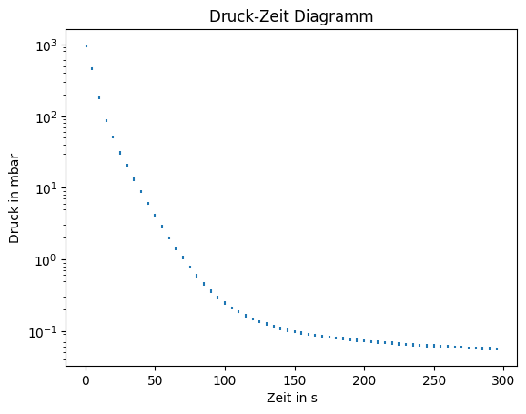

```python
#Import the meassured values and turning them into usable variables
df = pd.read_csv(r'Messung\2.1_T1_Messung.csv', delimiter=',')
time = df['t in sec']
pressure = df['p in mbar']

#Create the plot
plt.errorbar(time,pressure,yerr=0.05*pressure,xerr=0.196,ls='none')
plt.title('Druck-Zeit Diagramm')
plt.xlabel(('Zeit in s'))
plt.ylabel('Druck in mbar')
plt.yscale('log')
plt.show()
```

Im nächsten Schritt wird dann das Saugvermögen der Pumpe untersucht.

Laut [Datenblatt](https://gitlab.kit.edu/kit/etp-lehre/p2-praktikum/students/-/blob/main/Vakuum/Datenblatt.md) sind folgende Angaben zu der Apparatur 41 angegeben:

- Der Rezepientvolumen ist: $V_{RZ} = 10.1l$
- Der Volumen des Schlauches lässt sich als $V_{Schlauch} = 0.314l$ berechnen
- Zusätlichem Volumen durch den Aufbau: $0.5l$

Der Gesamt Volumen ist also: $V=10.914 l$

```python
#Define function to calculate S (equation 1)
def Saugvermoegen(t,p,p_0,V,t_0 = 0):
    return V/(t_0-t)*np.log(p/p_0)

#Define the error of S
def del_S(t,p,p_0,V,t_0=0):
    return V*np.sqrt(((0.05)/(t-t_0))**2+((0.196*np.log(p/p_0))/(t-t_0)**2)**2)

#Define function to calculate the mean of a list
def mean(list,start, finish):
    sum = 0
    i = 0
    for _ in range(start,finish+1):
        sum += list[_]
        i += 1
    return sum/i
```

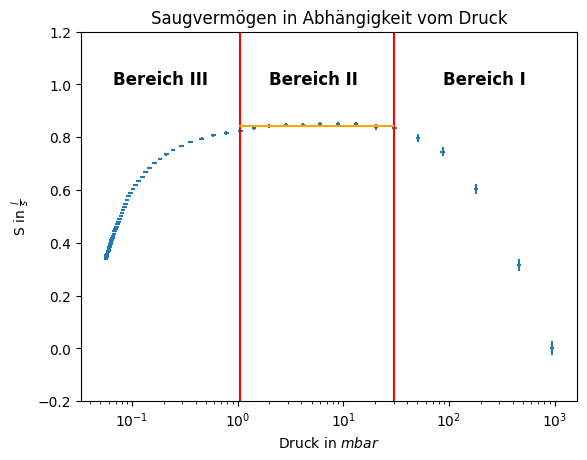

```python
#Calculate Volume from the given information
V=10.1+0.5+np.pi*(0.28/2)**2*5.10

#Generate a list for S and it's error
S = [Saugvermoegen(time[i]+20,pressure[i],p_0=pressure[0],V=V) for i in range(len(pressure))]
S_err= [del_S(time[i]+20,pressure[i],p_0=pressure[0],V=V) for i in range(len(pressure))]

#Create the Plot for S-p
plt.errorbar(x=pressure,y=S,xerr=0.05*pressure,yerr=S_err,ls='none')
plt.title('Saugvermögen in Abhängigkeit vom Druck')
plt.xlabel('Druck in $mbar$')
plt.ylabel(r'S in $\frac{{l}}{{s}}$')
plt.xscale('log')
plt.ylim(-0.2,1.2)

#Mark the three intervals
plt.axvline(x=pressure[5],color="red")
plt.axvline(x=pressure[14],color="red")
plt.axhline(y=mean(list=S,start=5,finish=14),xmin=0.32,xmax=0.63,color='orange')

#distinct naming of the intervals
plt.text(x=pressure[3],y=1,s='Bereich I',fontweight='bold',fontsize='large')
plt.text(x=pressure[12],y=1,s='Bereich II',fontweight='bold',fontsize='large')
plt.text(x=pressure[45],y=1,s='Bereich III',fontweight='bold',fontsize='large')

#Show end result
plt.show()
```

Die Graphik läst gut ersichtlich in drei Abschnitte zerteilen.  
In **Bereich I** ist zu sehen, dass das Saugvermögen mit abnehmendem Druck steigt.  
In **Bereich II** bleibt das Saugvermögen trotz abnahme des Druckes gleich.  
In **Bereich III** fält diese wieder je geringer der Druck wird.

Anschließend wird der zweite Bereich, da in diesem Bereich das Saugvermögen quasi-sonstant ist, genauer untersucht.

Hierfür werden diese Messpunkte zuerst isoliert verbildlicht.

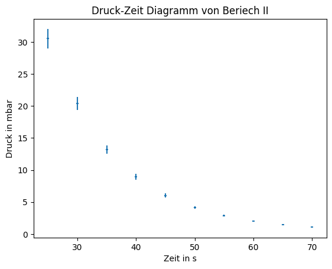

```python
plt.errorbar(time[5:15],pressure[5:15],yerr=0.05*pressure[5:15],xerr=0.196,ls='none')
plt.title('Druck-Zeit Diagramm von Beriech II')
plt.xlabel(('Zeit in s'))
plt.ylabel('Druck in mbar')
plt.show()
```

Unter der Annahme dass das Saugvermögen hier quasi-constant ist, wird ein Fit der Form $$ p(t)=p_0\cdot e^{-\frac SV\left(t-t_0\right)} $$ angebracht.

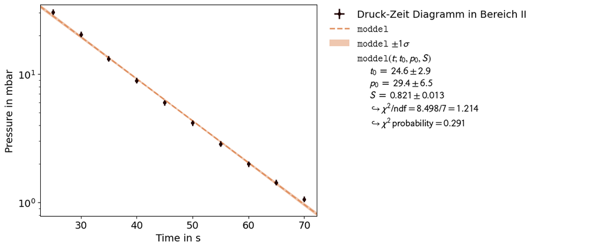

```python
# Define fit function
def moddel(t,t_0=time[5],p_0=pressure[5],S=mean(list=S,start=5,finish=15)):
    return p_0*np.exp(-(S)/(V)*(t-t_0))

# Dataset erstellen
dataset = kafe2.XYContainer(x_data=time[5:15],y_data=pressure[5:15])
dataset.axis_labels=['Time in s', 'Pressure in mbar']
dataset.label='Druck-Zeit Diagramm in Bereich II'

dataset.add_error(axis='x',err_val=0.196)
dataset.add_error(axis='y',err_val=0.05*pressure[5:15])



# Fit-Objekt erstellen
fit = kafe2.Fit(dataset,model_function=moddel)
fit.limit_parameter("t_0", lower=0)

# Fit durchführen
fit.do_fit()
fit_result=kafe2.Plot([fit])


# Fit-Ergebnisse plotten
fit_result.y_scale='log'
fit_result.plot()
plt.show()
```

##### Besprechung des Fits

Im Fit ergibt sich $S_{fit}=\left(0.821\pm0.013\right)\frac{l}{s}$ Der Literaturwert dagegen beträgt $S_{lit}=2.5\frac{m^3}{h}\approx 0.694\frac ls$. Dies liegt bei weitem außerhalb der ungenauigkeit des Wertes.

Urshachen dafür könnte die Ungenauigkeit des Messwerte sein, da diese per Hand aus dem Video ohne weitere Hilfsmittel entnommen wurden, oder auch die geringe Anzahl an Werte welche im Bereich II aufgezeichnet wurden.

### Aufgabe 2.2: Leitwert eines dünnen Rohrs

- Bei der Verbindungsleitung L [hier](https://gitlab.kit.edu/kit/etp-lehre/p2-praktikum/students/-/blob/main/Vakuum/figures/VakuumSkizze.png) handelt es sich im Originalaufbau um einen Metallwellschlauch. Tauschen Sie diesen gegen das bereitliegende etwa gleichlange dünne Metallrohr aus.
- Bestimmen Sie die Drucke $p_{1}$ (bei T1) vor und $p_{2}$ (bei T2) hinter dem Rohr als Funktion der Zeit.
- Bestimmen Sie aus den gewonnenen Daten den Leitwert des Rohrs als Funktion des Drucks.

**Lösung:**

#### Vorbereitung

##### Gesetz von Hagen-Poiseuille

Bei einem Druckuntershied zwischen zwei Seiten eines Volumenelements, kommt es zu eine Strömung eines sich darin befindendes Fluids mit einer vom Druckdifferenz abhängige Kraft $$ F =\pi r^2\left[ p \left( x+\mathrm dx \right) -p(x) \right] = \pi r^2 \mathrm dp $$

Entgegen dieser Kraft wirkt auf die Strömung die folgende Reibung aufgrund der Viskosität des Fluids.
$$ F_R = -\eta A\frac{\mathrm dv}{\mathrm dz} $$ In einem Zylinder (wie hier in dem Versuch) wird die Ableitung nach $\mathrm dz$ durch eine nach $\mathrm dr$ ersetzt, somit erhalten wir die folgende Gleichung: $$ F_R = -\eta 2\pi r\;\mathrm dx\frac{\mathrm dv}{\mathrm dr} $$

im stationären Fall ergeben die zwei Kräfte $F+F_R=0$ und die folgende Ortsableitung der Geschwindigkeit: $$ \frac{\mathrm dv}{\mathrm dr} = \frac{r}{2\eta}\frac{\mathrm dp}{\mathrm dx} $$

Durch die zwei Kräfte und resultiert dann ein Geschwindichkeitsprofil für unser FLuid: $$ v(r)= \int_R^r \frac{r}{2\eta}\;\frac{\mathrm dp}{\mathrm dx}\;\mathrm dr = \frac{r^2-R^2}{4\eta}\;\frac{\mathrm dp}{\mathrm dx} $$

Im zylindrischen Körper ergibt sich dann die folgendes Volumendurchfluss: $$ \dot V=\int_{0}^{2\pi}\int_{0}^{R}\frac{r^2-R^2}{4\eta}\;\frac{\mathrm dp}{\mathrm dx}r\;\mathrm d\phi\; \mathrm dr = -\frac{\pi R^4}{8\eta}\;\frac{\mathrm dp}{\mathrm dx} $$

Schaut man sich dem Massenfluss nach dem Seperationsansatz an $$ \int_0^l p\dot V\;\mathrm dx=-\int_{p_{ein}}^{p_{aus}} \frac{\pi R^4}{8\eta}p\;\mathrm dq $$ erhält man folgendes raus: $$ p\dot V= -\frac{\pi R^4}{8\eta l}\bar p\,\Delta p $$

mit $\bar p = \frac{p_{aus}+p_{ein}}2$ und $\,\Delta p =p_{aus}-p_{ein}$

##### Strömungsleitwert

Den Strömungsleitwert $L$ ist dann als der Proportionalitätsfaktor zwischen Saugleistung $S$ und und Druckdiferrenz $\Delta p$ gegebegen und lautet $$ L = \frac{\pi R^4\bar p}{8\eta l} $$

In den [Hinweisen](https://gitlab.kit.edu/kit/etp-lehre/p2-praktikum/students/-/blob/main/Vakuum/doc/Hinweise-Vakuum-a.md) wird gezeigt, dass sich der Stömungsleitwert $L$, der Volumenfluss $\dot V$, und $\frac{\mathrm dp}{\mathrm dx}$ Analoge zur Stromstärke $I$, Spannung $U$ und der Elektrischeleitwert $\sigma$ aus den Kirchhoffschen Regeln der E-Lehre sind.

##### Effektiver Saugvermögen

Da die DSP nicht direkt an dem Metallrohr verbunden ist, kann hier nicht mit dem Saugvermögen gearbeitet werden. Anstelle dessen wird das sogenante effektive Saugvermögen $S_{eff}$ $$ S_{eff} = \left( \frac 1L+\frac 1S \right)^{-1}= \frac{p_1}{p_2}S $$ eingeführt. $S_{eff}$ ergibt sich durch die Serienschaltung der Leitungselemente.

Formt man nach dem Stromleitwert um, erhält man dann folgende Gleichung: $$ \begin{equation} L = \frac{S\,S_{eff}}{S-S_{eff}} = \frac{p_1}{p_2-p_1}S \tag{2} \end{equation} $$

Dabei sind $p_1$ und $p_2$ die Messergebnisse von $T_1$ und $T_2$.

$$ L[\mathrm{l/s}] = 140\frac{d^4}{\ell}\overline p + 12.1\frac{d^{3}}{\ell} \cdot \frac{1+192\, d\, \overline{p}} {1+237\, d\, \overline{p}} \tag{3} $$

Ist eine Theoretische Gleichung (Knudsen-Gleichung) mit der man das Resultat vergleichen werden soll.

#### Durchführung

Der vorher verbindende Metallwellschlauch wurde nun durch ein sehr dünnes Rohr ausgetauscht und die Glocke wieder evakuiert. Danach wird über eine Zeitspanne von $5\,\mathrm{min}$ der Druck bei $T_1$ und $T_2$ gemessen. Diese werden dann wie davor bei Aufgabe 2.1 als $p(t)$-Diagramm dargestellt.

#### Auswertung

Es werden zunächst die Messdaten der jeweiligen Vakuummeter $T_1\,\&\,T_2$ geplottet.

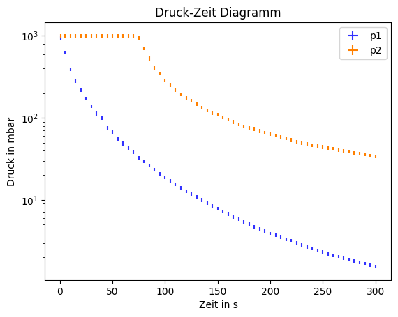

```python
#Import the meassured values and turning them into usable variables
df = pd.read_csv(r'Messung\2.2_T1-T2_Messung.csv', delimiter=',')
time_2 = df['t in sec']
pressure_1 = df['p1 in mbar']
pressure_2 = df['p2 in mbar']

#Create the plots
plt.errorbar(time_2,pressure_1,yerr=0.05*pressure_1,xerr=0.196,ls='none',color='#3232ff',label='p1')
plt.errorbar(time_2,pressure_2,yerr=0.05*pressure_2,xerr=0.196,ls='none',color='#ff8000',label='p2')

#Add legend

plt.title('Druck-Zeit Diagramm')
plt.xlabel(('Zeit in s'))
plt.ylabel('Druck in mbar')
plt.yscale('log')
plt.legend()
plt.show()
```

Anhand des Diagramms ist gut zu erkennen, dass sich der Druck an $T_2$ erst nach einer Minute anfängt sich überhaupt zu verändern.

Nun wird wie in Aufgabe 2.1 der Saugvermögen an $T_1$ und $T_2$ bestimmt.  
Dafür wird die Annahme getroffen, dass sich das dünne Rohr lediglich durch die Dicke zun dem Wellschlauch unterscheidet.

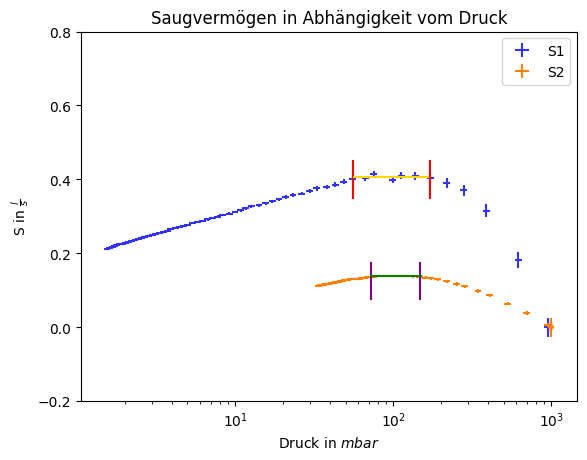

```python
#Calculate Volume from the given information
thin_pipe_r, thin_pipe_l =(0.02/2), 5.10 # Both measurements in dm
V_2=10.1+0.5+np.pi*thin_pipe_r**2*thin_pipe_l # in liters

#Generate a list for S and it's error
S_1 = [Saugvermoegen(time_2[i]+20,pressure_1[i],p_0=pressure_1[0],V=V_2) for i in range(len(pressure_1))]
S_2 = [Saugvermoegen(time_2[i]+20,pressure_2[i],p_0=pressure_2[0],V=V_2) for i in range(len(pressure_2))]

S_err_1= [del_S(time_2[i]+20,pressure_2[i],p_0=pressure_2[0],V=V_2) for i in range(len(pressure_2))]
S_err_2= [del_S(time_2[i]+20,pressure_2[i],p_0=pressure_2[0],V=V_2) for i in range(len(pressure_2))]

#Create the PlotsF for S-p
plt.errorbar(x=pressure_1,y=S_1,xerr=0.05*pressure_1,yerr=S_err_2,ls='none',color='#3232ff',label='S1')
plt.errorbar(x=pressure_2,y=S_2,xerr=0.05*pressure_2,yerr=S_err_2,ls='none',color='#ff8000',label='S2')

plt.title('Saugvermögen in Abhängigkeit vom Druck')
plt.xlabel('Druck in $mbar$')
plt.ylabel(r'S in $\frac{{l}}{{s}}$')
plt.xscale('log')
plt.ylim(-0.2,0.8)

#Seperate the three intervals for S1
plt.axvline(x=pressure_1[5],ymin=0.55,ymax=0.65,color="red")
plt.axvline(x=pressure_1[11],ymin=0.55,ymax=0.65,color="red")
plt.axhline(y=mean(list=S_1,start=5,finish=11),xmin=0.55,xmax=0.7,color='gold')

#Seperate the three intervals for S2
plt.axvline(x=pressure_2[26],ymin=0.275,ymax=0.375,color="purple")
plt.axvline(x=pressure_2[37],ymin=0.275,ymax=0.375,color="purple")
plt.axhline(y=mean(list=S_2,start=26,finish=37),xmin=0.585,xmax=0.685,color='green')

#Show end result
plt.legend()
plt.show()
```

An dem Diagramm von $S_2$ lässt sich ein bereich mit einen quasi-constant Wert sehr gut erkennen. Im Diagramm wurde dieser Intervall eingerahmt und mit einer Ausgleichsgerade versehen. Es ist zu erkennen, dass es in diesem Bereich sehr geringe abweichungen von der Geraden gibt.  
An dem Diagramm von $S_1$ dagegen ist ein solcher Bereich nicht gut zu erkennen. Es wurde aber der beriech oben gefunden. Wie bei $S_2$ wird es ebenfalls mit einer Ausgleichsgerade versehen. Hier ist zu erkennen, dass die Abweichung einzelner Werte größer ist. Betrachtet man den Verlauf von $S_1$, lässt sich dies aber als grobe Ungenauigkeit der Messung erschließen.  
Bei dem Schauen des Videos kann ein weiterer Grund erschlossen werden. Bei geringem Druck verlaufen die Werte nicht mehr monoton sinkend. Es kommt zu schwingungen der Werte zu größere Werte. Es kann sein, dass bei der Auswertung solche Frames erwicht wurden, wodurch die Messung an Ungenauigkeit gewann.

Es werden jetzt anschließend die Fits gemacht.

$\displaystyle \text{Aus dem Fit ergibt sich } S_1=\left(0.418\pm0.0265\right)$

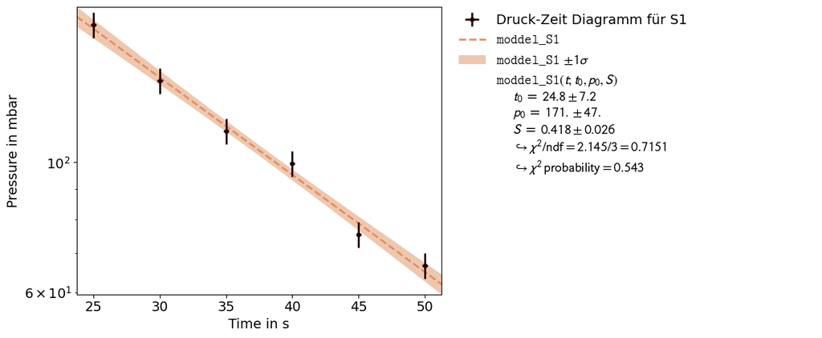

```python
# Define fit function
def moddel_S1(t,t_0=time_2[5],p_0=pressure_1[5],S=mean(list=S_1,start=5,finish=11)):
    return p_0*np.exp(-(S)/(V)*(t-t_0))

# Create Dataset
dataset_S1 = kafe2.XYContainer(x_data=time_2[5:11],y_data=pressure_1[5:11])
dataset_S1.axis_labels=['Time in s', 'Pressure in mbar']
dataset_S1.label='Druck-Zeit Diagramm für S1'

dataset_S1.add_error(axis='x',err_val=0.196)
dataset_S1.add_error(axis='y',err_val=0.05*pressure_1[5:11])



# Create Fit
fit_S1 = kafe2.Fit(dataset_S1,model_function=moddel_S1)
fit_S1.limit_parameter("t_0", lower=0)
fit_S1.do_fit()
fit_result_S1=kafe2.Plot([fit_S1])

# Get Fit Variables and their errors
params_1=fit_S1.parameter_values
params_err_1=fit_S1.parameter_errors

# Fit-Ergebnisse plotten
fit_result_S1.y_scale='log'
fit_result_S1.plot()
display(Math(rf'\text{{Aus dem Fit ergibt sich }} S_1=\left({params_1[2]:.04}\pm{params_err_1[2]:.4f}\right)'))
plt.show()
```

$\displaystyle \text{Aus dem Fit ergibt sich } S_2=\left(0.1431\pm0.0105\right)$

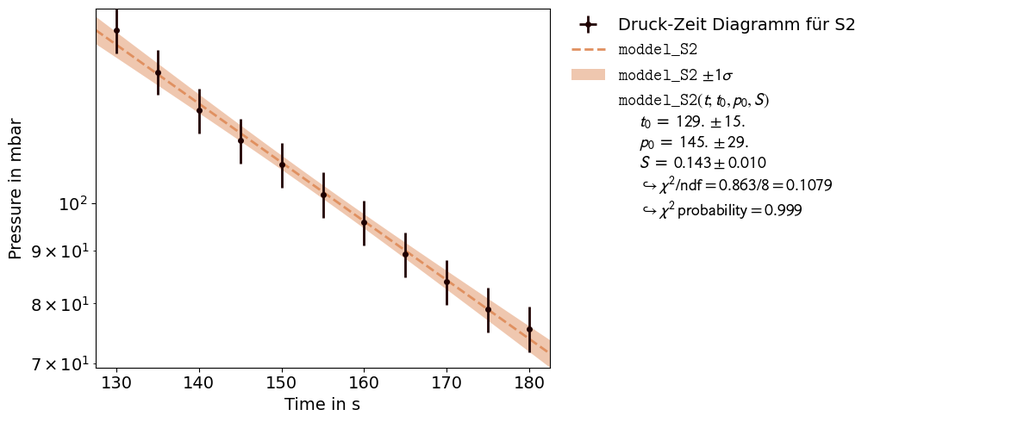

```python
# Define fit function
def moddel_S2(t,t_0=time_2[26],p_0=pressure_2[26],S=mean(list=S_2,start=26,finish=37)):
    return p_0*np.exp(-(S)/(V)*(t-t_0))

# Dataset erstellen
dataset_S2 = kafe2.XYContainer(x_data=time_2[26:37],y_data=pressure_2[26:37])
dataset_S2.axis_labels=['Time in s', 'Pressure in mbar']
dataset_S2.label='Druck-Zeit Diagramm für S2'

dataset_S2.add_error(axis='x',err_val=0.196)
dataset_S2.add_error(axis='y',err_val=0.05*pressure_2[26:37])



# Fit-Objekt erstellen
fit_S2 = kafe2.Fit(dataset_S2,model_function=moddel_S2)
fit_S2.limit_parameter("t_0", lower=0)

# Fit durchführen
fit_S2.do_fit()
fit_result_S2=kafe2.Plot([fit_S2])

# Get Fit Variables and their errors
params_2=fit_S2.parameter_values
params_err_2=fit_S2.parameter_errors

# Fit-Ergebnisse plotten
fit_result_S2.y_scale='log'
fit_result_S2.plot()
display(Math(rf'\text{{Aus dem Fit ergibt sich }} S_2=\left({params_2[2]:.04}\pm{params_err_2[2]:.4f}\right)'))
plt.show()
```

Aus den zwei Werten für das Saugvermögen lässt sich der Strömungsleitwert $L$ gemäß $\text{Glch.} (2)$ ausrechnen.

```python
# Declare new variables for easer use
S1_from_fit = params_1[2]
S2_from_fit = params_2[2]

# Calculate and display L with it's error
L = (S1_from_fit*S2_from_fit)/(S1_from_fit-S2_from_fit)

L_par_S1 = -(S2_from_fit**2)/((S1_from_fit-S2_from_fit)**2)
L_par_S2 = (S1_from_fit**2-(2*S1_from_fit*S2_from_fit))/((S1_from_fit-S2_from_fit)**2)
L_err = np.sqrt((L_par_S1*params_err_1[2])**2+(L_par_S2*params_err_2[2])**2)

display(Math(rf'\text{{Aus den durch Fits ermittelte Saugvermögen, lässt sich }} L=({L:.06f}\pm{L_err:.04f})\frac ls\, \text{{bestimmen}}'))

# Calculate L using equation 3
L_lit = 140*((thin_pipe_r*2))**4/(thin_pipe_l)*(mean(list=(pressure_2+pressure_1)/2,start=0,finish=60))+12.1*(thin_pipe_r*2)**3/(thin_pipe_l)*((1+192*(thin_pipe_r*2)*(mean(list=(pressure_2+pressure_1)/2,start=0,finish=60)))/(1+237*(thin_pipe_r*2)*(mean(list=(pressure_2+pressure_1)/2,start=0,finish=60))))

display(Math(rf'\text{{Mithilfe der theoretischen Gleichung lässt sich }} L_{{theo}}={L_lit:.06f}\frac ls\, \text{{berechnen}}'))
```

$\displaystyle \text{Aus den durch Fits ermittelte Saugvermögen, lässt sich } L=(0.217535\pm0.0105)\frac ls\, \text{bestimmen}$

$\displaystyle \text{Mithilfe der theoretischen Gleichung lässt sich } L_{theo}=0.000923\frac ls\, \text{berechnen}$

### Aufgabe 2.3: Saugvermögen der TMP

- Nehmen Sie die TMP in Betrieb und bestimmen Sie analog zu **Aufgabe 2.1** das Saugvermögen der TMP als Funktion des Drucks bei IM.
- Stellen Sie S(p) für die DSP und die TMP in einem Diagramm graphisch dar und diskutieren Sie Ihr Ergebnis.
- Schätzen Sie die Kraft ab, mit der die Glasglocke auf die Gummidichtung gedrückt wird.

**Lösung:**

#### Vorbereitung

Um das Saugvermögen der TMP zu bestimmen wird zur Messung die IM verwendet.

Zuerst wird die Apparatur belüftet bis sich ein druck von $\sim 0.2\mathrm{mbar}$ einstellt.  
Danach wird dies mit der DSP auf einem Druck von $\sim0.08\mathrm{mbar}$ abgepumpt. Nach erreichen diesem Drucks wird die TMP eingeschaltet.

Am IM wird dann alle $5\mathrm{sec}$ der Druck aufgezeichnet.

Andschließend soll ein $S(p)$-Diagramm analog zu dem in Aufgabe 2.1 erstellt werden damit die zwei $S(p)$-Diagramme anschließend verglichen werden.

#### Auswertung

[output not shown]

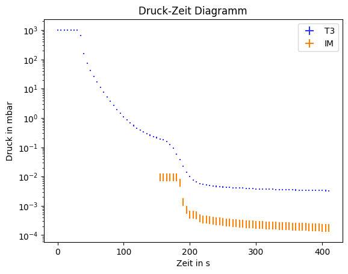

```python
#Import the meassured values and turning them into usable variables
df = pd.read_csv(r'Messung\2.3_T3-IM_Messung.csv', delimiter=',')
time_3 = df['time in sec']
pressure_T3 = df['T3 in mbar']
pressure_IM = df['IM in mbar']

T3_err = [0.05 if i >= 1e-3 else 0.1 for i in pressure_T3]

#Create the plots
plt.errorbar(time_3,pressure_T3,yerr=T3_err*pressure_T3,xerr=0.196,ls='none',color='#3232ff',label='T3')
plt.errorbar(time_3,pressure_IM,yerr=0.3*pressure_IM,xerr=0.196,ls='none',color='#ff8000',label='IM')


plt.title('Druck-Zeit Diagramm')
plt.xlabel(('Zeit in s'))
plt.ylabel('Druck in mbar')
plt.yscale('log')

plt.legend()
plt.show()
```

Dem Plot ist schnell zu entnehmen, dass die Messwerte an dem $IM$ und $T_3$ voneinander getrennt sind und diese sich auch nicht in die Unsicherheiten des jeweils anderem zu finden sind. Auch bei der TMP ist Anlaufzeit zu erkennen, diese beträgt $\approx 25$ Sekunden.

Als nächstes folgt ein Plot der unterschiedlichen Saugvermögen der Pumpen. Hierfür wird der Saugvermögen der DSP, bis zum Zeitpunkt bevor die TMP angeschaltet wurde, mit ihre Messwerte, welche an $T_3$ ermittelt wurden, und die TMP, welche einmal bei $T_3$ und einmal am $IM$ abgelesen wird, gegen den vorherschenden Druck geplottet.

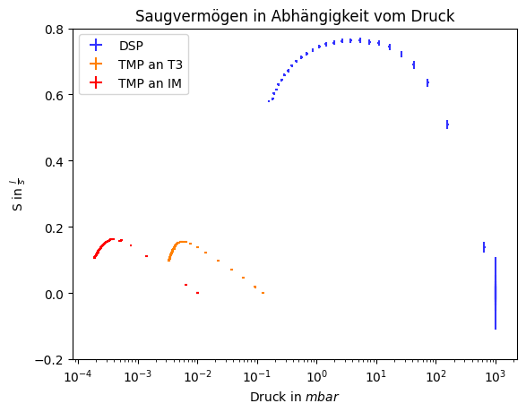

```python
# Make Datasets with their error
S_DSP = [Saugvermoegen(time_3[i],pressure_T3[i],p_0=pressure_T3[0],V=V) for i in range(0,34)]
S_TMP_T3 = [Saugvermoegen(time_3[i],pressure_T3[i],p_0=pressure_T3[34],V=V) for i in range(34,83)]
S_TMP_IM = [Saugvermoegen(time_3[i],pressure_IM[i],p_0=pressure_IM[34],V=V) for i in range(34,83)]

S_err_DSP= [del_S(time_3[i],pressure_T3[i],p_0=pressure_T3[0],V=V) for i in range(0,34)]
S_err_TMP_T3= [del_S(time_3[i],pressure_T3[i],p_0=pressure_T3[0],V=V) for i in range(34,83)]
S_err_TMP_IM= [del_S(time_3[i],pressure_IM[i],p_0=pressure_IM[0],V=V) for i in range(34,83)]

#Create the PlotsF for S-p
plt.errorbar(x=pressure_T3[0:34],y=S_DSP,xerr=0.05*pressure_T3[0:34],yerr=S_err_DSP,ls='none',color='#3232ff',label='DSP')
plt.errorbar(x=pressure_T3[34:83],y=S_TMP_T3,xerr=0.05*pressure_T3[34:83],yerr=S_err_TMP_T3,ls='none',color='#ff8000',label='TMP an T3')
plt.errorbar(x=pressure_IM[34:83],y=S_TMP_IM,xerr=0.05*pressure_IM[34:83],yerr=S_err_TMP_IM,ls='none',color='#ff0000',label='TMP an IM')

plt.title('Saugvermögen in Abhängigkeit vom Druck')
plt.xlabel('Druck in $mbar$')
plt.ylabel(r'S in $\frac{{l}}{{s}}$')
plt.xscale('log')
plt.ylim(-0.2,0.8)

#Show end result
plt.legend()
plt.show()
```

Es wird schnell ersichtlich, dass sich das Saugvermögen sehr stark vom Druck abhängt. Die DSP hat zwar ein viel höheres Saugvermögen, dieser fällt aber sehr stark ab mit sinkendem Druck. Dagegen hat die TMP zwar einen deutlich geringeren Saugevermögen, ist aber bei sehr geringem Druck einsetzbar. Wie man auch sehen kann, sie die gemessenen Saugevermögen der TMP an $T_3$ und $IM$ bis auf eine Verschiebung im Druckbereich identisch.

#### Berechnung der Kraft auf die Glasglocke

Um die Kraft, mit welcher die Glasglocke auf die Gummidichtunug drückt zu bestimmen, wird der Druckunterschied zwischen dem äßußeren der Glocke und der Innenraum bestimmt.  
Die Fläsche um der es sich hier handelt ist eine Kreißfläsche, welche parallel zur Gummidichtung steht.  
Die Kraft lässt sich einfach als Druck pro Fläsche bestimmen. Hier wird der Innendruck zu einem Vakuum genähert und wird für die Rechnung vernachläßigt. Dafür wird von der mittlere Luftdruck der Atmosphäre ($\approx 1\mathrm{bar}$) ausgegangen.

Folgende Daten sind zur Glocke gegeben:

| Daten | Größe |
| --- | --- |
| Durchmesser | $0.22\mathrm{m}$ |
| Höhe | $0.25\mathrm{m}$ |

```python
# Create variables to handle all numbers
r = 0.11
p_atmo = 101325
Area = np.pi*r**2

# Calculate the Force and display it
F = Area*p_atmo

display(Math(rf'\text{{Es ergibt sich eine Kraft von}}\,F={F:.02f}N'))
```

$\displaystyle \text{Es ergibt sich eine Kraft von}\,F=3851.69N$

## Aufgabe 3: Experimente im Vakuum

**Hinweise zu Aufgabe 1 finden in der Datei Hinweise-Versuchsdurchfuehrung.md.**

- Für diese Aufgabe führen Sie einige einfache Experimente im Vakuum durch.
- Bearbeiten Sie hierzu die folgenden Aufgaben.

### Aufgabe 3.1: Statische Kalibration von T3

Führen Sie mit Hilfe des Referenzvolumes RV eine statische Kalibration des Vakuummeters T3 durch.

**Lösung:**

#### Vorbereitung

Um den Druck nach jeder itteration zu bestimmen, wird das Boyle-Mariottesche Gesetz verwendet. Bei einen konstanten Temperatur lautet dies: $$ p_1V_1=p_2V_2 $$

Im Versuch wird p_1 als Atmospharendruck $p_0$ und $V_1$ als RV eingesetzt.

Der Verdichtungsverhältnis des Systems wird durch die Gleichung $$ \epsilon =\frac{\Delta p}{p_0} $$ gegeben.
Es wird ein linearer Zusammenhang vermutet. Aber aufgrund von der Leckrate des Aufbaus, wird dies möglicherweise nicht der Fall sein.

Es gilt folgende Veränderung des Drucks nach jeder Iteration:

$$ \begin{split} &\bigl(p_{\mathrm{RZ}}+\Delta p\bigr)\,\bigl(V_{\mathrm{RZ}}+V_{\mathrm{RV}}\bigr) = \bigl(n_{\mathrm{RZ}}+n_{\mathrm{RV}}\bigr)\,R\,T \\ &\\ &\text{mit:}\\ &\\ &n_{\mathrm{RZ}} = \frac{p_{\mathrm{RZ}}\,V_{\mathrm{RZ}}}{R\,T}\qquad n_{\mathrm{RV}} = \frac{p_{0}\,V_{\mathrm{RV}}}{R\,T} \\ &\\ &\bigl(p_{\mathrm{RZ}}+\Delta p\bigr)\,\bigl(V_{\mathrm{RZ}}+V_{\mathrm{RV}}\bigr) = p_{\mathrm{RZ}}\,V_{\mathrm{RZ}}+p_{0}\,V_{\mathrm{RV}}\\ &\\ &V_{\mathrm{RV}} = \frac{\Delta p\,V_{\mathrm{RZ}}}{p_{0}-\left(p_{\mathrm{RZ}}+\Delta p\right)}\approx\frac{\Delta p\,V_{\mathrm{RZ}}}{p_{0}} \\ &\\ &\epsilon=\frac{\Delta p}{p_{0}}\approx\frac{V_{\mathrm{RV}}}{V_{\mathrm{RZ}}} \\ \end{split} $$

#### Durchführung

Es werden $V_3$ geschlossen und $B_2$.  
Danach wird RZ mithife beider Pumpen (DSP & TMP) evakuiert.

Nachdem ein Druck von $p\lesssim 10^{-4}mbar$ erreicht wird, wird $V_2$ geschlossen um die Pumpe abzutrennen.

1. Nun werden $B_2$ geschlossen und $V_3$ geöffnet. Nachdem sich der Druck dann einstellt, wird dies bei $T_3$ abgelesen.
2. Nachdem dies abgelesen wird, wird daraufhin $V_3$ geschlossen und $B_2$.  
   Daraufhin stellt sich dann der Atmospharendruck $p_0$ im Referenzvolumen (RV) ein.

Diese zwei Schritte werden stehts wiederholt bis sich im RZ ein Druck von $\sim \mathrm{80mbar}$ einstellt.

Der Verlauf des Drucks wird dann in der Auswertung als Funktion der Iterationen $i$ dargestellt.  
Daruas wird dann auch das Verdichtungsverhältnis bestimmt.

#### Auswertung

```python
# List of pressures as well as generating ammount of steps
p_3 = np.array([3.80,8.09,12.5,17.6,22.6,28.5,35.4,43.8,49.3,59.5,66.0,76.4,90.7 ])
steps = np.linspace(1,13,13)
```

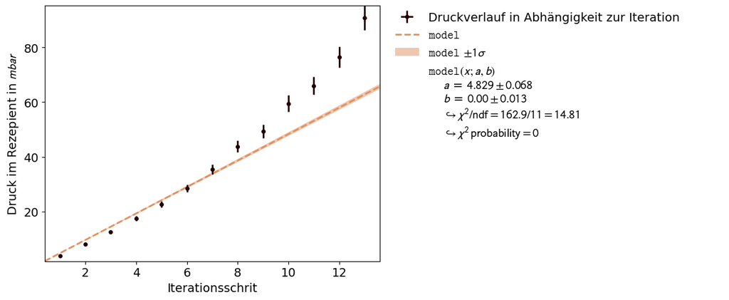

```python
# Define the model funktion
def model(x,a,b):
    return x*a+b

# Make Dataset
dataset_31 = kafe2.XYContainer(x_data=steps,y_data=p_3)
dataset_31.axis_labels=['Iterationsschrit', 'Druck im Rezepient in $mbar$']
dataset_31.label='Druckverlauf in Abhängigkeit zur Iteration'

dataset_31.add_error(axis='x',err_val=0)
dataset_31.add_error(axis='y',err_val=0.05*p_3)

# creating Fit
fit_31 = kafe2.Fit(dataset_31,model_function=model)
fit_31.limit_parameter('b', lower=0)

fit_31.do_fit()
fit_result_31=kafe2.Plot([fit_31])

# Get Parameter a
a = fit_31.parameter_values[0]

# Plot Fit Results
fit_result_31.plot()
plt.show()
```

Wie an der $\chi^2$-probablity zu sehen ist, ist der Fit sehr schlecht ausgefallen. Es besteht kein linearer Zusammenhang zwischen den gemessenen Daten und der Erwartung. Dennoch ist aus dem Versuchsaufbau klar, dass dies in guter Näherung der Fall sein sollte.  
In dieser Messreihe ist der lineare Bereich in den ersten 5 Iterationen erkennbar. Nach dem Vergleichen mit den Messwerten anderer Gruppen ist dieses Phänomän mehrmals aufgekommen.

Eine Vermutung weshalb die gewünschte Linearität hier nicht erscheint sind mögliche Lecks im System wodurch der Druck im System unerwünscht erhöht.  
Der Parameter $a$ wird also weiterhin für die Gleichung angenommen.

Es wird nun wie in der Vorbereitung das Verdichtungsverhältnis $\epsilon$ ausgerechnet.

Dies wird sowohl über $\epsilon = \frac{\Delta p}{p_0}$ als auch über $\epsilon\approx\frac{V_{RV}}{V_{RZ}}$ gemacht.

```python
# Create needed variables
p_0 = 1013.25 # Pressure in mbar
V_RV = 0.034 # in liters
V_RZ = 10.1 # in liters

# Calculate epsilon via both ways
e_1 = a/p_0
e_2 = V_RV/V_RZ

display(Math(rf'\text{{Über den Druck kommt man auf:}}\,\epsilon={e_1:.04E}\qquad \text{{Dagegen durch die Volumina auf}}\,\epsilon={e_2:.04E}'))

display(Math(rf'\text{{Die Abweichung der zwei Werte beträgt:}}\;{(e_1/e_2-1)*100:.02f}\%'))
```

$\displaystyle \text{Über den Druck kommt man auf:}\,\epsilon=4.7663E-03\qquad \text{Dagegen durch die Volumina auf}\,\epsilon=3.3663E-03$

$\displaystyle \text{Die Abweichung der zwei Werte beträgt:}\;41.59\%$

### Aufgabe 3.2: Elektrische Durchschlagfestigkeit

- Bestimmen Sie die elektrische Durchschlagfestigkeit der KE als Funktion des Umgebungsdrucks in Luft.
- Diese Aufgabe kann nur an den Apparaturen 41 und 42 durchgeführt werden.

**Lösung:**

#### Vorbereitung

Bei dem anlegen einer hinreichend großen Spannung zwischen zwei Körper, Entladen sich diese duch einen Funken.  
Im Versuch wird dieses Phänomen in Abhängigkeit vom anliegenden Druck geprüft.

Der Entladungsprozess ist vom [Druck abhängig](https://de.wikipedia.org/wiki/Durchschlagfestigkeit). Dementsprechend, wird vermutet, dass die dazu benötigte Spannung mit dem Druck sinkent wird.

Es werden zwei Entladungsprozesse erwartet:

- Funkenentladung wie sie unter normalen Bedingungen gesehen wird (bsp. Blitze)
- Glimmentladung bei niedrigem Druck

Die beobachtbare Glimmladung ist kann nur bei niedrigem Druck entstehen, da es im Vakuum eine geringe Menge and Luftteilchen gibt und somit die geringere Wahrscheinlichkeit, dass ein Elektron mit einem dieser Teilchen stößt.

Zur Bestimmung der mittleren freien Weglänge $\lambda$ wird folgende formel verwendet:

\begin{equation*} \begin{split} &\lambda = \frac{1}{\sigma\,n} = \frac{k_{B}\,T}{\sigma\,p_{\mathrm{RZ}}};\\ &\\ &\text{mit:}\\ &\\ &\sigma= \pi\,r^{2};\qquad r=\sqrt[3]{\frac{3}{4\pi}V}; \qquad V= \frac{M_{m}\,f}{N_{A}\,\rho_{\mathrm{fl}}},\\ \end{split} \end{equation*}

wobei $N_{A}$ der [Avogradro-Konstanten](https://de.wikipedia.org/wiki/Avogadro-Konstante), $M_{m}$ der [molaren Masse](https://de.wikipedia.org/wiki/Molare_Masse), $\rho$ die Dichte vom Gas und $f$ als Füllfaktor.

#### Durchführung

Das RZ wird zuerst mit dem DSP evakuiert. Stehts nach erreichen des gewünschten Drucks, wird dann $V_1$ geschlossen, damit der Druck im laufe der Messung konstant bleibt.

Die Messung wird zuerst mit geöffnete Ventile bei Atmosphärendruck durchgefürt. Danach wird der Druck zwischen den einzelnen Messungen stehts halbiert.

Ab einem Druck von $\sim 0.08\mathrm{mbar}$ wird dann die TMP ebenfalls angeschaltet um einen Druck von $p\lesssim 10^{-4}\mathrm{mbar}$ erreicht wird.  
Anschließend wird dann $V_2$ geschlossen.  
Aufgrund der Leckrate des Vakuums wird der Druck stehtig aufsteigen. Während dies geschieht, werden weitere Messwerte aufgezeichnet mit der Bedingung, dass die Spannung $U\leq 9\mathrm{kV}$ bleibt.  
Diese Messreihe endet beim erreichen des Drucks $p\sim 0.08\mathrm{mbar}$

#### Auswertung

```python
# Defining needed constants
k_B = 1.380649E-23 # in J pro K
T = 298.15 # Temp during measurements in K
N_A = 6.02214076E23 # pro Mol
M_m = 28.96 # Molar mass of the atmospheric air

R = N_A*k_B # universal gas constant
f = (2e2)/(R*T) # Füllfaktor eines Gases
```

```python
Volt = np.array([4.357,0.807,0.793,0.706,0.585,0.475,0.402,0.395,0.378,0.341,0.473,0.511,0.598,0.522,0.567])# in kV
    # Multimeter * 10
pressure = np.array([1000,490,255,125,61.3,31.0, 15.7,7.75,3.83,1.88,0.911,0.45,0.225,0.117,0.055])# in mbar

# rest of voltage : ,1.1,0.8,0.76,0.72
```

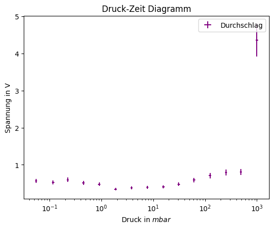

```python
#Create the plot
plt.errorbar(x = pressure,y=Volt,yerr=0.1*Volt,xerr=0.05*pressure,ls='none',color='purple',label='Durchschlag')

# finetuning the Plot
plt.title('Druck-Zeit Diagramm')
plt.xlabel(('Druck in $mbar$'))
plt.ylabel('Spannung in V')
plt.xscale('log')

plt.legend()
plt.show()
```

So sieht der Diagramm soweit mit den Messwerten alleine von $T_3$ um die Messwerte zu vervollständigen, werden die Messungen im Hochvakuum dazu genommen.  
Um Diese Messwerte zu bestimmen, wird zuerst das Diagramm aus Aufgabe 2.3 zur Hand genommen. Anhand des Diagramms, wird der Punkt bestimmt, bei dem die Werte des IMs verwendet werden sollen. Diese Stelle charakterisiert sich dadurch, dass hier der Abstand zwischen den Messwerten des $IM\mathrm s$ und die von $T_3$ minimal wird.

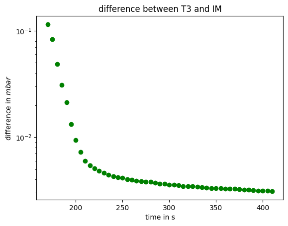

$\displaystyle \text{Der Mindestabstand 3.10E-03 wird hier an der Stelle: 48 gefunden.}$

$\displaystyle \text{An dieser Stelle misst der IM den Wert 3.16E-04mbar}$

```python
difference = np.array([pressure_T3[34:]-pressure_IM[34:]])

plt.scatter(x=time_3[34:],y=difference,color='green')

plt.title('difference between T3 and IM')
plt.xlabel('time in s')
plt.ylabel('difference in $mbar$')
plt.yscale('log')

plt.plot()
plt.show()

display(Math(rf'\text{{Der Mindestabstand {np.min(difference):.02E} wird hier an der Stelle: {np.argmin(difference)} gefunden.}}'))
display(Math(rf'\text{{An dieser Stelle misst der IM den Wert {pressure_IM[48]:.02E}mbar}}'))
```

Mit dieser gewonnenen Erkenntnis, wird nun das Diagramm verfolständigt. Zudem wird noch in dieser Darstellung der Wert bei $p=10^3$ ausgelassen, damit die Parabel-Form etwas besser zu sehen wird.  
Gäbe es mehr Messwerte zu diesem Versuch, würde es viel schöner aussehen. Das ist weil man sehen würde, dass die linke Seite der Parabel ebenfalls sehr stark steigt.

```python
Volt = np.array([0.807,0.793,0.706,0.585,0.475,0.402,0.395,0.378,0.341,0.473,0.511,0.598,0.522,0.567,1.1,0.8,0.76,0.72])*1000# in V
    # Multimeter * 10
pressure = np.array([490,255,125,61.3,31.0, 15.7,7.75,3.83,1.88,0.911,0.45,0.225,0.117,0.055,0.00226,0.00249,0.00276,0.00708])*100# in pascal
```

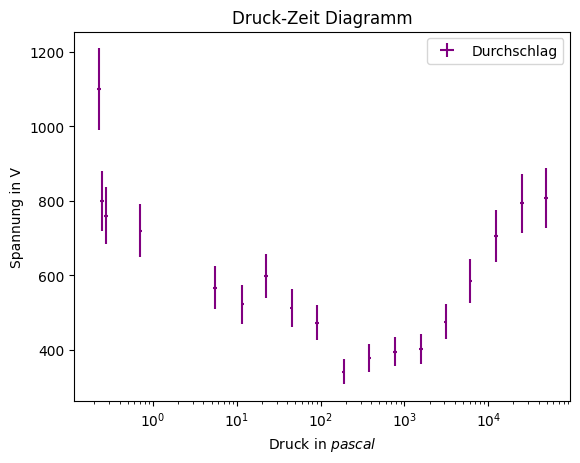

```python
#Create the new plots
plt.errorbar(x = pressure,y=Volt,yerr=0.1*Volt,xerr=0.05*pressure,ls='none',color='purple',label='Durchschlag')

# finetuning the Plot
plt.title('Druck-Zeit Diagramm')
plt.xlabel(('Druck in $pascal$'))
plt.ylabel('Spannung in V')
plt.xscale('log')

plt.legend()
plt.show()
```

Zwar sind die Messwerte sehr schlecht, aber dennoch ist hier die gesuchte Parabelform zu finden.  
Der Abfall der Kurve lässt sich über die steigende mittlere freie Weglänge begründen.

Bei größer werdende MFW (mittlere freie Weglänge) brauchen die Elektronen weniger Beschleunigung im E-Feld um einen Durchschlag zu erzeugen. Durch die geringere Anzahl an Kolisionen ist auch keine sehr hohe Spannung mehr notwendig um die Elektronen ausreichend zu beschleunigen, damit diese Ionisation im Gas auslösen.

Bei sehr niedrigem Druck gibt es weniger Gasmoleküle im Abstand zwischen den Elektroden. Die mittlere freie Weglänge der Elektronen ist größer, was dazu führt, dass Elektronen die notwendige Energie nicht ausreichend durch Stöße aufnehmen können, um Ionisation zu verursachen. Dies erfordert eine höhere Durchschlagspannung.

Um die mittlere freie Weglänge bei dem Druck $p_{min} = 200\mathrm{pascal}$ zu berechnen, wird folgender Rechenweg verwendet:

```python
rho = (2E2*M_m)/(R*T)
V = (M_m*f)/(N_A*rho)
r_gas = np.cbrt((3)/(4*np.pi)*V)
sigma = np.pi*r_gas**2

weglaenge = (k_B*T)/(sigma*2E2)

display(Math(rf'\text{{Durch die Messung erhält man eine mittlere freie Weglänge von}}\,\lambda={weglaenge:.04E}'))
```

$\displaystyle \text{Durch die Messung erhält man eine mittlere freie Weglänge von}\,\lambda=1.2140E-07$

Es kommt eine Weglänge von $\lambda \sim 1.214\cdot 10^{-7}=0.1214\,\mathrm{\mu m}$. Das ist ein erschtaunlich kleiner Abstand. Obwohl dieser Wert den Abstand zwischen den KE sein ist er so gering.  
Ursache für diesen falschen Wert könnte der sehr ungenaue Messverfahren sein. Es musste alles mit relativ großer Ungenauigkeit per hand gemessen und aufgezeichnet werden. Der Multimeter liefert auch keine genaue Werte, da sich diese beim Entladen sehr stark schanken.

### Aufgabe 3.3: Aufdampfen von Indium

Dampfen Sie mit Hilfe einer Schablone bei zwei verschiedenen Drucken Indium auf eine Plexiglasplatte auf.

**Lösung:**

#### Vorbereitung

Es wird nun ein Indium Fleck bei einem Druck von $\dots$

- $p\leq 10^{-4}\mathrm{mbar}$
- $p\leq10^{-3}\mathrm{mbar}$

$\dots$ aufgedampft.

Ähnlich wie bei Aufgabe 3.2 wird auch hier Aufgrund der unterschiedlichen mittleren freien Weglänge $\lambda$ von verschiedene Ergebnisse ausgegangen.

#### Durchführung

Das RZ wird zu begin mithilfe der TMP Evakuiert bis der herschende Druck auf $\sim 10^{-4}$ fällt. Danach wird der Ventil $V_2$ geschlossen und der erste Fleck bei diesem Druck aufgedampft.

Als nächstest wird etwas Luft durch $B_2$ eingelassen damit ein Vakuum mit $p\sim 10^{-3}\mathrm{mbar}$ erreicht wird. Der zweite Fleck wird dann unter diesem Druck aufgedampft.

Am ende wird die Randschärfe der jeweiligen Flecken untersucht.

#### Auswertung

[figure not shown]

**Abbildung 3.3.1:** Aufnahmen der Indium Flecke. Links bei $p\leq10^{-4}\mathrm{mbar}$ und rechts bei $p\leq10^{-3}\mathrm{mbar}$

Wie bereits in der Vorbereitung vermutet, zeigt sich ein Unterschied.  
Das im Vakuum mit dem Druck $p\leq10^{-4}\mathrm{mbar}$ entsandene Fleck hat sehr scharfe Kanten wogegen der Fleck beim Druck $p\leq10^{-3}\mathrm{mbar}$ dagegen sogut wie keine Kanten aufweisst.

Das liegt daran, dass sich die mittlere freie Weglänge $\lambda$ geändert hat und bei dem höheren Druck es zu viele Stöße zwischen dem Damp und die Gaß Atome kam. Hingegen geschah eine solche Wechselwirkung im geringeren Druck fast nie.